# Homework Comments

Yuanting Lu

Last updated 04/18/2023

# Homework 1

## Chapter 1

### #6

1. Biased.
2. Biased.
3. **Good.**
4. Biased. Volunteer sampling.
5. Biased. What about people who don’t have home telephones?

## Section 2.2

### #1

```r
size <- c(5, 13, 9, 12, 7, 4, 8, 6, 6, 10, 7, 11, 10, 8, 15,
8, 6, 9, 12, 10, 7, 11, 10, 8, 12, 9, 7, 10, 7, 8)
table(size)
```

```
## size
##  4  5  6  7  8  9 10 11 12 13 15
##  1  1  3  5  5  3  5  2  3  1  1
```

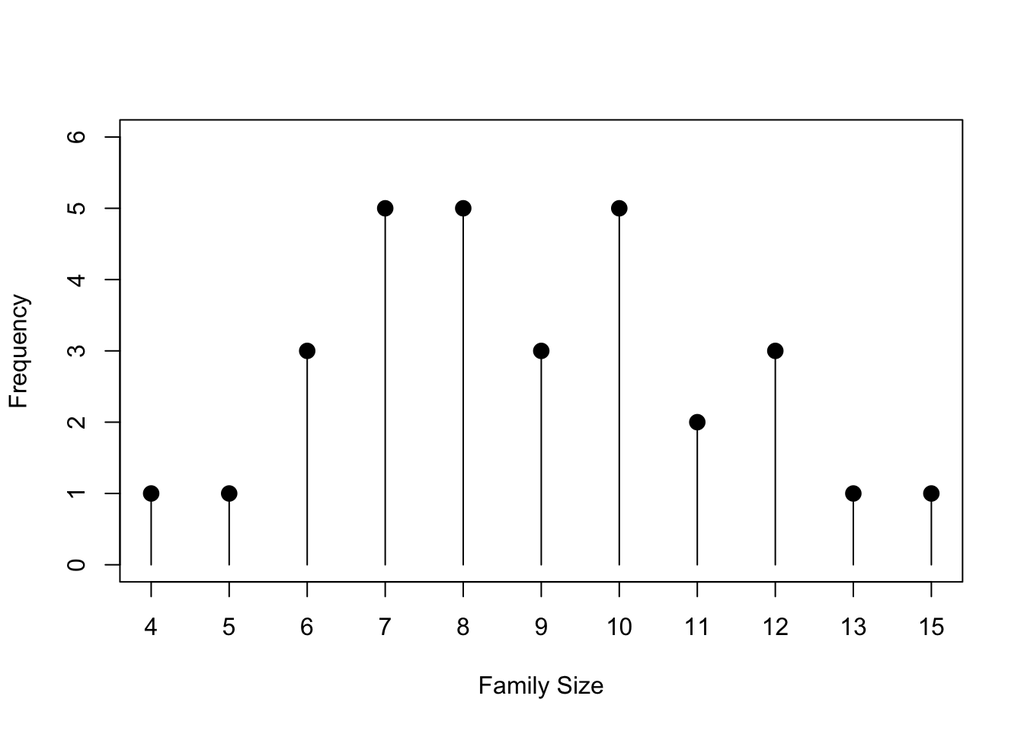

```r
source("https://albums.yuanting.lu/sta126/20fa/nicer.R")
lollipop(table(size),
         breaks = 3.5:15.5,
         ylim = c(0, 6), xlab = "Family Size")
```

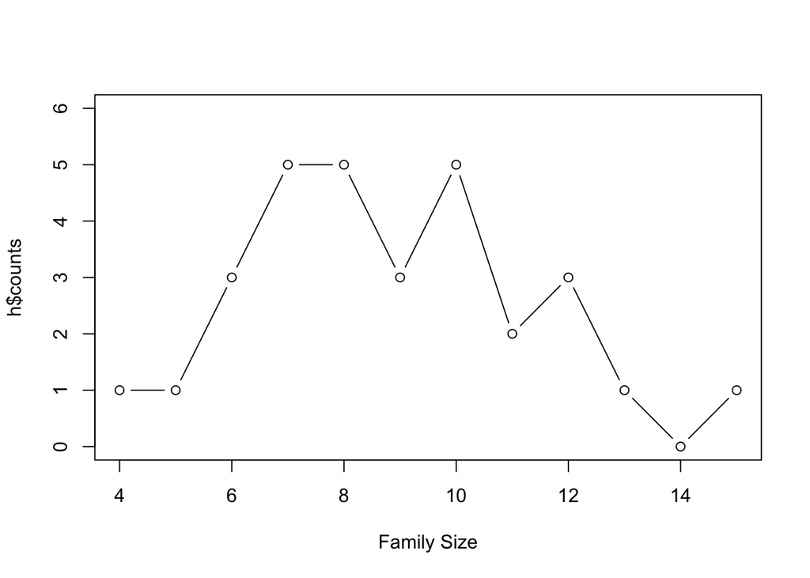

```r
freqpoly(size,
         breaks = 3.5:15.5,
         ylim = c(0, 6), xlab = "Family Size")
```

### #3

3. 9
4. 6

## Section 2.3

### #1

The right = FALSE makes all the intervals left inclusive, i.e., $[90, 100), [100, 110), [110, 120), [120, 130), [130, 140), [140, 150)$, so that 100 belongs to the second bin instead of the first bin.

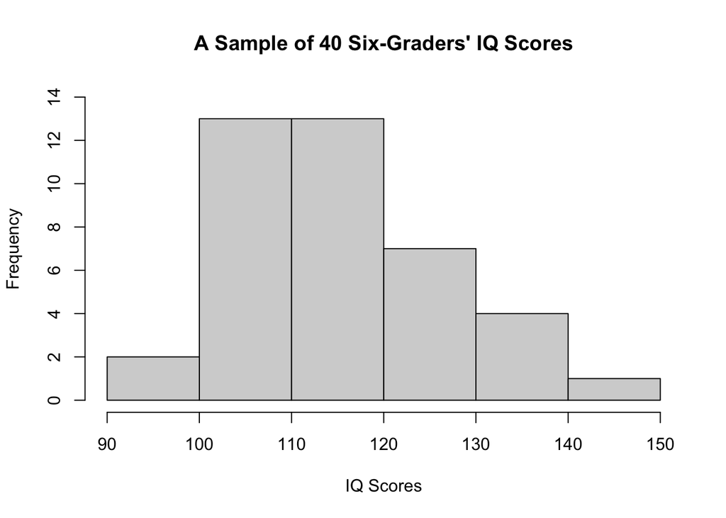

```r
iq <- c(114, 122, 103, 118, 99, 105, 134, 125, 117, 106, 109, 104, 111, 127,
133, 111, 117, 103, 120, 98, 100, 130, 141, 119, 128, 106, 109, 115,
113, 121, 100, 130, 125, 117, 119, 113, 104, 108, 110, 102)
hist(iq, breaks = c(90, 100, 110, 120, 130, 140, 150),
     ylim = c(0, 14), xlab = "IQ Scores", right = FALSE,
     main = "A Sample of 40 Six-Graders' IQ Scores")
```

### #3

Don’t forget to add meaningful x-axis labels and titles.

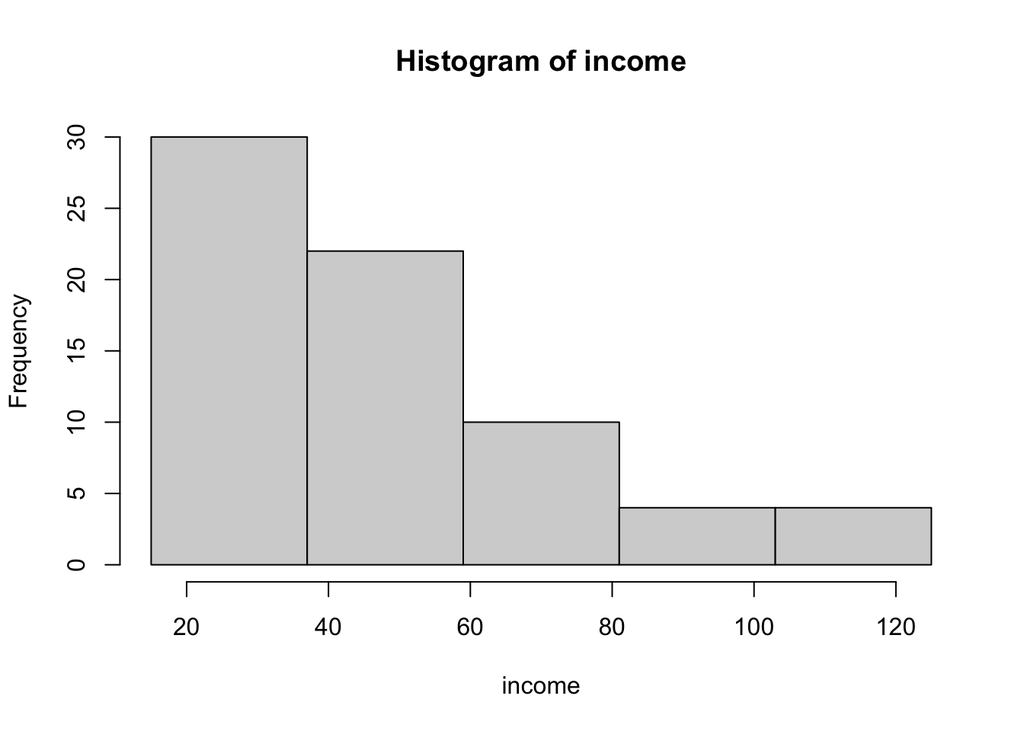

```r
income <- c(47, 55, 18, 24, 27, 41, 50, 38, 33, 29, 15, 77, 64, 22, 19, 35, 39, 41,
67, 55, 121, 77, 80, 34, 41, 48, 60, 30, 22, 28, 84, 55, 26, 105, 62,
30, 17, 23, 31, 28, 56, 64, 88, 104, 115, 39, 25, 18, 21, 30, 57, 40,
38, 29, 19, 46, 40, 49, 72, 70, 37, 39, 18, 22, 29, 52, 94, 86, 23, 36)
hist(income, breaks = c(15, 37, 59, 81, 103, 125), right = FALSE)
```

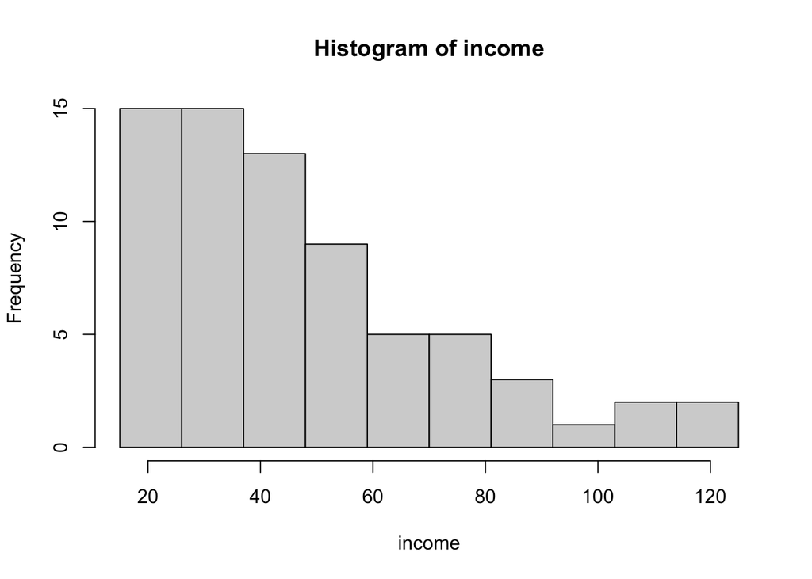

```r
hist(income, breaks = c(15, 26, 37, 48, 59, 70, 81, 92, 103, 114, 125), right = FALSE)
```

## Section 3.2

### #11

The mean is 6.5 fires.

### #17

$\dfrac{30\times 73600 + 20 \times 92400}{50}$. This is called a weighted average.

## Section 3.3

### #11

The histograms on the book are bad examples. There should be **no gap** between the bins.

- If you think the bins are based on the following intervals [15, 16), [16, 17), [17, 18), [18, 19), [19, 20), [20, 21), [21, 22), [22, 23), [23, 24), [24, 25], then the book answers make sense.
  1. Use the largest possible value on each interval, i.e., 16, 17, …, 25.
     $$\dfrac{16\times 1 + 17\times 3 + 18
     \times 3 + 19 \times 4 + 20 \times 6 + 21 \times 4 + 22 \times 3 + 23
     \times 5 + 24 \times 2 + 25\times 3}{34}$$
  2. Use the largest possible value on each interval, i.e., 16, 17, …, 25.
  3. Use the smallest possible value on each interval, i.e., 15, 16, …, 24.
  4. Use the smallest possible value on each interval, i.e., 15, 16, …, 24.
- Otherwise, if you believe the bins are based on the following intervals [14.5, 15.5), [15.5, 16.5), [16.5, 17.5), [17.5, 18.5), [18.5, 19.5), [19.5, 20.5), [20.5, 21.5), [21.5, 22.5), [22.5, 23.5), [23.5, 24.5], then your answers will be
1. 20.24
2. 20
3. 19.24
4. 19

## Section 3.3.1

### #9

- If you use `quantile(..., 0.75, type = 2)`, you will find $Q3=92$ as stated in the book answers.
- If you use `fivenum(...)`, you will find $Q3$ to be $91.5$. Either one is fine.

# Homework 2

## Section 4.3

### #13

0.31 or 31%

# Homework 3

## Section 4.7

### #1

175760000

### #5

FYI: In 1995, the North American Numbering Plan Administrator (NANP) removed the requirement that the middle digit of an area code had to be either 0 or 1. Here is [a map of all the area codes in 1947](http://www.lincmad.com/map1947.html). (What was Georgia’s area code in 1947?) So, before 1995,

- There are 144 possible area codes.
- There are 18 starting with a 4.

### #11

1. 5
2. 0.6

### #13

Hint: This is very similar to the lottery example we covered in class. Starting with dividing the chips into two piles: the 86 good ones and the 14 defective ones.

1. 0.2045541
2. 0.3719165
3. 0.4235294

### #17

Hint: Another similar problem of the lottery example we covered in class. The questions can be divided into two categories: the 7 questions the student knows how to solve and the 3 questions that the student doesn’t know how to solve.

1. 0.0833333
2. 0.5

## Section 4.5

### #11

12/2028 = 0.0059172

The event that two cards are of different suits has $52\times 39 = 2028$ outcomes. (The first card can be any of the 52 cards. But once the first card is drawn, the second card is limited to one of the oher three suits, i.e., one of 39 cards.)

Of those 2028 outcomes, 12 are corresponding to both cards are aces. (The first card can be any of the four aces, then the second card can be any of the rest three aces.)

## Section 5.3

### #29

Let $X$ be the number of cakes sold. If the bakery bakes 2 cakes daily, then the probability distribution of $X$ is

| $X$ | $P(X)$ |
| --- | --- |
| 0 | 0.15 |
| 1 | 0.25 |
| 2 | 0.6 |

- If no cake is sold, the profit is $-4\times 2 = -8$ dollars. (Probability 0.15)
- If one cake is sold, the profit is $20 - 4\times 2 = 12$ dollars. (Probability 0.25)
- If both cakes are sold, the profit is $20\times 2 - 4 \times 2=32$ dollars. (Probability 0.6)

Therefore, if two cakes are baked daily, the expected profit is
$$-8(0.15) + 12(0.25) + 32(0.6)=\$21.$$

Repeat the same process (reconstruct the probability distribution table) to find the expected profit for baking 3 and 4 cakes, separately. (Answer: $23 if 3 cakes are baked daily and $22 if 4 cakes are baked daily).

# Homework 4

## Section 7.4

### #9

Based on the given information, the sample size is $n=50$, the population mean is $\mu=0$, and the population standard deviation is $\sigma=\sqrt{\frac{1}{12}}$. (Note: standard deviation is the square root of variance.) According to the Central Limit Theorem, the sampling distribution of sample means will have a mean of $\mu = 0$ and a standard deviation of $\sigma_{\tiny \overline{x}}=\frac{\sigma}{\sqrt{n}}=\frac{\sqrt{1/12}}{\sqrt{50}}$.

If the sum of the 50 numbers in the sample differs from the exact sum by 3, then the sample mean $\overline{x}$ differs by $3/50=0.06$, meaning $\overline{x}$ is either larger or smaller than the true sum by 0.06. Therefore,

$P(|\overline{x}-\mu|>0.06)=P(|\overline{x}|>0.06)=P(\overline{x}>0.06)+P(\overline{x}<-0.06)$

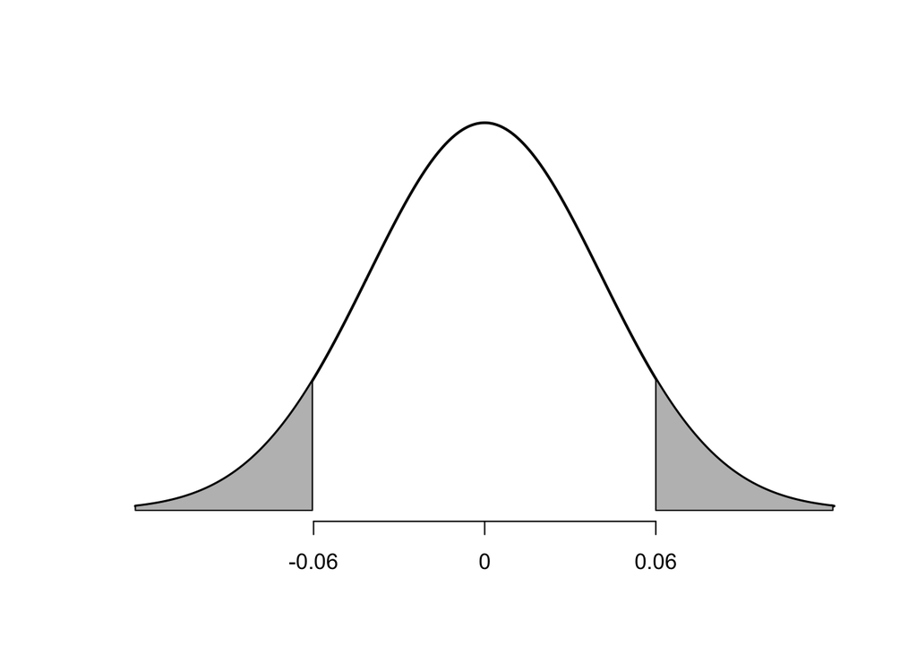

```r
1 - pnorm(0.06, 0, sqrt(1/12) / sqrt(50)) + pnorm(-0.06, 0, sqrt(1/12) / sqrt(50))
```

```
## [1] 0.1416447
```

## Section 8.7

### #19(a)

```r
   (qnorm(0.95) * sqrt(0.5 * (1 - 0.5)) / 0.02) ^ 2
```

1691

# Homework 5

## Section 9.5

### #1

Let $p$ be the true proportion of patients who get effective treatment by using the new drug.

- $H_0: p = 0.72$
- $H_1: p>0.72$
- P-value:

```r
1 - pbinom(41, 50, 0.72)
```

```
## [1] 0.03645886
```

```r
1 - pnorm(41.5/50, 0.72, sqrt(0.72 * 0.28 / 50))
```

```
## [1] 0.04160677
```

Conclusion: Based on a 0.05 significance level, the p-value is small. We reject the null hypothesis. There is sufficient evidence to show that the new drug is more effective than the old one.

### #3

- P-value = 0.262 (Binomial).
- P-value = 0.256 (Normal approximation with continuous correction).

### #5

- (b). P-value = 0.136
- (c). P-value = 0.052
- (d). P-value = 0.004

### #9

- P-value = 0.292 (Binomial).
- P-value = 0.314 (Normal approximation with continuous correction).

### #11

- P-value = 0.17

### #15

- P-value = 0 (round to three decimal places).

# Homework 6

## Section 9.4

### #1

P-value = 0.260

### #7

P-value = 0.00076

### #13

P-value = 0.0694

### #15

P-value = 0.0068

# Homework 7

## Section 10.4

### #1

- Let $\mu_1$ be the true systolic blood pressure for all smokers.
- Let $\mu_2$ be the true systolic blood pressure for all nonsmokers.
- $H_0: \mu_1 = \mu_2$
- $H_1: \mu_1 \ne \mu_2$

```r
s <- c(124, 134, 136, 125, 133, 127, 135, 131, 133, 125, 118)
ns <- c(130, 122, 128, 129, 118, 122, 116, 127, 135, 120, 122, 120, 115, 123)
t.test(s, ns, alternative = "two.sided")
```

```
##
##  Welch Two Sample t-test
##
## data:  s and ns
## t = 2.5239, df = 21.636, p-value = 0.01947
## alternative hypothesis: true difference in means is not equal to 0
## 95 percent confidence interval:
##   1.033961 10.615390
## sample estimates:
## mean of x mean of y
##  129.1818  123.3571
```

- Based on a significance level of 0.01, the p-value is not small. We do not reject the null hypothesis. There is no sufficient evidence to show that the mean systolic blood pressure levels are different between smokers and nonsmokers.
- Based on a significance level of 0.05, the p-value is small. We reject the null hypothesis. There is sufficient evidence to show that the mean systolic blood pressure levels are different between smokers and nonsmokers.

### #3

```r
generic <- c(14.2, 14.7, 13.9, 15.3, 14.8, 13.6, 14.6, 14.9, 14.2)
name <- c(14.3, 14.9, 14.4, 13.8, 15.0, 15.1, 14.4, 14.7, 14.9)
t.test(generic, name, alternative = "greater")
t.test(name, generic, alternative = "less")
```

## Section 10.5

### #1

```r
before <- c(73, 67, 68, 60, 76, 80, 73, 77, 66, 58, 82, 78)
after <- c(77, 69, 73, 70, 74, 88, 76, 82, 69, 61, 84, 80)
t.test(before, after, alternative = "two.sided", paired = TRUE)
```

```
##
##  Paired t-test
##
## data:  before and after
## t = -4.2197, df = 11, p-value = 0.001437
## alternative hypothesis: true difference in means is not equal to 0
## 95 percent confidence interval:
##  -5.705997 -1.794003
## sample estimates:
## mean of the differences
##                   -3.75
```

## Section 10.6

### #1

```r
prop.test(c(20, 12), c(100, 100), alternative = "two.sided")
```

```
##
##  2-sample test for equality of proportions with continuity correction
##
## data:  c(20, 12) out of c(100, 100)
## X-squared = 1.8229, df = 1, p-value = 0.177
## alternative hypothesis: two.sided
## 95 percent confidence interval:
##  -0.03100948  0.19100948
## sample estimates:
## prop 1 prop 2
##   0.20   0.12
```

## Section 12.3

### #5

2. If you subtract the years by 1995 as the book suggested, the linear regression line is $y = 0.9321x+25.65$. (Otherwise, if you don’t subtract the years by 1995, the regression line is $y = 0.9321x - 1833.975$.)

   ```r
   year <- c(0, 1, 2, 3, 4, 5, 6, 7)
   pp <- c(25.9, 26.8, 27.3, 27.8, 29.6, 30.5, 30.8, 32.6)
   lm(pp ~ year)
   ```

   ```
   ##
   ## Call:
   ## lm(formula = pp ~ year)
   ##
   ## Coefficients:
   ## (Intercept)         year
   ##     25.6500       0.9321
   ```

3. Plot

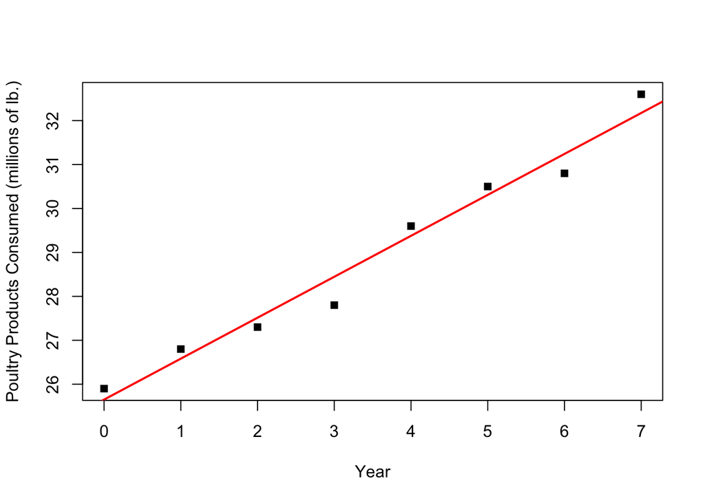

   ```r
   plot(pp ~ year, pch = 15,
    xlab = 'Year',
    ylab = "Poultry Products Consumed (millions of lb.)")
   abline(lm(pp ~ year), col = 'red', lwd = 2)
   ```

4. 24.7179 million pounds (or 24.6324).
5. 34.0389 million pounds (or 33.9534).

### #15

The probability is for someone who worked 42 years is 0.3.